# The Iconic Data Scientist Test Solution

Sajjad Syed

2019-02-27

# Data Scientist Task

Task description and data for candidates applying to be a Data Scientist in the Data Science and Analytics Department at The Iconic.

## Background

Many of our customers at THE ICONIC - similar to most online shoppers - only provide the bare minimum of information needed when signing up as a new user or making a transaction on the site (i.e credit card details, delivery address etc). They do not provide their age, gender or any other personal details when they register as a new customer or they will simply purchase their items as a Guest user.

Respecting customer privacy is of the utmost important at THE ICONIC and we understand why some shoppers are hesitant to provide personal information. However, to be able to better tailor our site, branding strategy, marketing, product and most importantly merchandising, we need to have a better handle on the profile of our shopper and understand the things that are more relevant to them.

**What we have identified here is an opportunity to infer customers gender based on the amazingly rich user behavioural data, which will allow us to better tailor our site and offerings to their needs.**

This way, the customer will be able to control their privacy and while still allowing us to tailor our offerings more suitably to our customer’s needs.

There are two main ways to gauge customer behaviour:

**Purchase Behaviour**: Identify what they purchase, how do they purchase it, frequency, what price points, what discount types resonate etc. **Visit Behaviour**: This includes behaviour on site, the way shoppers browse, the types of interactions respond to etc. Here are a host of such features that can be engineered, but for now, this should suffice. Using the dataset given, can you predict an “inferred” gender for our customers?

## Task

There are four stages to this task:

**Stage 1** : SQL - A lot of our data lives in SQL databases, data scientists need to be comfortable using SQL.

Unhash the sqlite database (test_data.db.zip) using the secret key provided by us, extract it.

Write SQL queries to answer the following questions:

Note: At this stage it is ok to ignore the underlying errors in the data

What was the total revenue to the nearest dollar for customers who have paid by credit card? What percentage of customers who have purchased female items have paid by credit card? What was the average revenue for customers who used either iOS, Android or Desktop? We want to run an email campaign promoting a new mens luxury brand. Can you provide a list of customers we should send to? **Stage 2** : CLEAN - Unhash the data (test_data.zip) using the secret key provided by us, extract it, most importantly clean it and put it in a form you can use - all programatically of course. We have also “intentionally” corrupted two columns in this file - two columns that might look correct but are not correct. They need “some correction” to be useful.

**Stage 3** : BUILD - Build a deep learning model (preferably) or any other model that suitably answers this question and predict the inferred gender using the features provided and deriving more featueres at your end. Remember, there is no gender flag, so you are flying blind here.

**Stage 4** : DELIVER - Package all your process, findings and code into a reproducible document that can be understood by a business user. A repo of the code branch would be a great thing to have! This reproducible report* must answer the following questions:

How did you clean the data and what was wrong with it? Close to 90% of a Data Scientist’s job is in cleaning data What are the features you used as-is and which one did you engineer using the given ones? What do they mean in the real world? What does the output look like - how close is the accuracy of the prediction in light of data with labelled flags? What other features and variables can you think of, that can make this process more robust? Can you make a recommendation of top 5 features you’d seek to find apart from the ones given here Summarize your findings in an executive summary

## Solution

### Stage 1:

At this stage, my first task was to import the SQLITE database **test_data.db.zip** provided and run the queries to answer four business questions. First I unpacked the password i.e;unserialized lowercase SHA-256 hash using the keyword provided.

To run the **test_data.db**, I installed and loaded the package named **RSQLite**. Depending on your system, you may or may not have it. If you don’t have it you can install and load using the following script

```r
#install.packages("RSQLite") #perhaps needed

library("RSQLite")
```

After installing the package,we will import the file using the following script

```r
# connect to the sqlite database file
#I am using my system file path you can replace it with filepath in your system
filename<-"C:/Users/syeds/Documents/My Docs/Iconic Job/datascientist-master/datascientist-master/test_data.db/test_data.db"

#/Users/sajjad/Documents/Iconic Test/datascientist-master/test_data.db   Mac filepath
#C:/Users/syeds/Documents/My Docs/Iconic Job/datascientist-master/datascientist-master/test_data.db/test_data.db  windows filepath


#store the driver in sqlite
sqlite    <- dbDriver("SQLite")

#import the database in the Iconic_Database_Test
Iconic_Database_Test <- dbConnect(sqlite,dbname=filename)
```

Checking the Data in the Iconic_Database_Test

```r
#Getting the List of Tables in the Database
dbListTables(Iconic_Database_Test)
```

```
## [1] "customers"
```

```r
#Getting the List of all the Columns in the CUstomers Table
dbListFields(Iconic_Database_Test,"customers")
```

```
##  [1] "customer_id"              "days_since_first_order"
##  [3] "days_since_last_order"    "is_newsletter_subscriber"
##  [5] "orders"                   "items"
##  [7] "cancels"                  "returns"
##  [9] "different_addresses"      "shipping_addresses"
## [11] "devices"                  "vouchers"
## [13] "cc_payments"              "paypal_payments"
## [15] "afterpay_payments"        "apple_payments"
## [17] "female_items"             "male_items"
## [19] "unisex_items"             "wapp_items"
## [21] "wftw_items"               "mapp_items"
## [23] "wacc_items"               "macc_items"
## [25] "mftw_items"               "wspt_items"
## [27] "mspt_items"               "curvy_items"
## [29] "sacc_items"               "msite_orders"
## [31] "desktop_orders"           "android_orders"
## [33] "ios_orders"               "other_device_orders"
## [35] "work_orders"              "home_orders"
## [37] "parcelpoint_orders"       "other_collection_orders"
## [39] "redpen_discount_used"     "coupon_discount_applied"
## [41] "average_discount_onoffer" "average_discount_used"
## [43] "revenue"
```

*Question 1*: What was the total revenue to the nearest dollar for customers who have paid by credit card?

```r
#The Query and Output
dbGetQuery(Iconic_Database_Test,'SELECT  SUM(revenue) as Revenue
                                 FROM customers
                                 WHERE cc_payments<>0'
           )
```

```
##    Revenue
## 1 50372282
```

*Question 2*: What percentage of customers who have purchased female items have paid by credit card?

```r
#The Query and Output
dbGetQuery(Iconic_Database_Test,'SELECT  Round (AVG(CASE WHEN cc_payments=1 THEN 1 ELSE 0 END ) *100,2)
                                        as Percentage_Of_Credit_Card_Payments
                                FROM customers
                                WHERE female_items<>0'
           )
```

```
##   Percentage_Of_Credit_Card_Payments
## 1                              65.43
```

*Question 3*: What was the average revenue for customers who used either iOS, Android or Desktop?

```r
#The Query and Output
dbGetQuery(Iconic_Database_Test,'SELECT  round(avg(revenue),2) as Average_Revenue
                                 FROM customers
                                 WHERE (desktop_orders<>0 OR ios_orders <>0 OR android_orders <>0)'
           )
```

```
##   Average_Revenue
## 1         1484.89
```

*Question 4*: We want to run an email campaign promoting a new mens luxury brand. Can you provide a list of customers we should send to?

```r
#The Query and I have hidden the result because it will take too much space in the Markdown File

Output<-dbGetQuery(Iconic_Database_Test,'SELECT   distinct customer_id
                                 FROM  customers
                                 WHERE male_items <>0 or unisex_items <> 0'
           )

# This is the list of customers
Output

#The Selection Criteria here is subjective. My assumption is both Men and Unisex customer can be targeted.
#We can target female customers if we are running the campaign during the valentines day. There is good chance of them
#looking for a gift as well.Furthermore, we can go on and filter the data for just customers having price per  male item high
```

### Stage 2:

CLEAN - Unhash the data (test_data.zip) using the secret key provided by us, extract it, most importantly clean it and put it in a form you can use - all programatically of course. We have also “intentionally” corrupted two columns in this file - two columns that might look correct but are not correct. They need “some correction” to be useful.

Before starting the Cleaning Process, I will install and load all the packages that i will be using throughout the model development.

```r
# Install package function: it will installs and load multiple R packages.
# Install the package if they are not istalled, then load them into the R session.
r = getOption("repos")
r["CRAN"] = "http://cran.us.r-project.org"
options(repos = r)

Install_Packages <- function(package){
  new.package <- package[!(package %in% installed.packages()[, "Package"])]
  if (length(new.package))
    install.packages(new.package,dependencies = TRUE)
  sapply(package, require, character.only = TRUE)
}


packages <- c("readr", "jsonlite", "ggplot2", "dplyr", "tidyverse", "cluster","factoextra","gridExtra","corrplot","randomForestExplainer")
Install_Packages(packages)


install.packages("devtools")
library(devtools)
devtools::install_github('araastat/reprtree')
library(reprtree)



#library(readr)
#library(jsonlite)   # for reading json file
#library(ggplot2)    # plotting the data
#library(dplyr)      # data manipulation
#library(tidyverse)  # data manipulation
#library(cluster)    # clustering algorithms
#library(factoextra) # clustering algorithms & visualization
#library(gridExtra)  # displaying multiple k value clusters at once
#library(corrplot)
```

Now we will import the Json file provided for data analysis and inspect it and try to find the issues if any in our data

```r
Iconic_Test_Data<-fromJSON("C:/Users/syeds/Documents/My Docs/Iconic Job/datascientist-master/datascientist-master/test_data/data.json")

#/Users/sajjad/Documents/Iconic Test/datascientist-master/data.json  Mac filepath

#C:/Users/syeds/Documents/My Docs/Iconic Job/datascientist-master/datascientist-master/test_data/data.json windows file path

#convert the data into dataframe

Iconic_Test_Data = data.frame(Iconic_Test_Data)

#check the data summary statistics

summary(Iconic_Test_Data)
```

```
##  customer_id        days_since_first_order days_since_last_order
##  Length:46279       Min.   :   1           Min.   :   24
##  Class :character   1st Qu.: 910           1st Qu.: 6816
##  Mode  :character   Median :1713           Median :25560
##                     Mean   :1374           Mean   :24593
##                     3rd Qu.:1786           3rd Qu.:41640
##                     Max.   :2164           Max.   :51840
##
##  is_newsletter_subscriber     orders            items
##  Length:46279             Min.   :  1.000   Min.   :  1.000
##  Class :character         1st Qu.:  1.000   1st Qu.:  1.000
##  Mode  :character         Median :  2.000   Median :  3.000
##                           Mean   :  4.108   Mean   :  8.575
##                           3rd Qu.:  4.000   3rd Qu.:  7.000
##                           Max.   :665.000   Max.   :701.000
##
##     cancels            returns        different_addresses
##  Min.   :  0.0000   Min.   :  0.000   Min.   :0.0000
##  1st Qu.:  0.0000   1st Qu.:  0.000   1st Qu.:0.0000
##  Median :  0.0000   Median :  0.000   Median :0.0000
##  Mean   :  0.0531   Mean   :  1.622   Mean   :0.1166
##  3rd Qu.:  0.0000   3rd Qu.:  1.000   3rd Qu.:0.0000
##  Max.   :460.0000   Max.   :343.000   Max.   :1.0000
##
##  shipping_addresses    devices         vouchers        cc_payments
##  Min.   : 1.000     Min.   :1.000   Min.   : 0.0000   Min.   :0.0000
##  1st Qu.: 1.000     1st Qu.:1.000   1st Qu.: 0.0000   1st Qu.:0.0000
##  Median : 1.000     Median :1.000   Median : 0.0000   Median :1.0000
##  Mean   : 1.501     Mean   :1.277   Mean   : 0.9403   Mean   :0.6424
##  3rd Qu.: 2.000     3rd Qu.:1.000   3rd Qu.: 1.0000   3rd Qu.:1.0000
##  Max.   :15.000     Max.   :3.000   Max.   :57.0000   Max.   :1.0000
##
##  paypal_payments  afterpay_payments apple_payments       female_items
##  Min.   :0.0000   Min.   :0.00000   Min.   :0.0000000   Min.   :  0.000
##  1st Qu.:0.0000   1st Qu.:0.00000   1st Qu.:0.0000000   1st Qu.:  0.000
##  Median :0.0000   Median :0.00000   Median :0.0000000   Median :  2.000
##  Mean   :0.4909   Mean   :0.05344   Mean   :0.0005618   Mean   :  6.466
##  3rd Qu.:1.0000   3rd Qu.:0.00000   3rd Qu.:0.0000000   3rd Qu.:  5.000
##  Max.   :1.0000   Max.   :1.00000   Max.   :1.0000000   Max.   :537.000
##
```

[output cut: 49 more lines]

```
##  Min.   :  0.000         Min.   :     0.00    Min.   :    0.0
##  1st Qu.:  1.000         1st Qu.:     0.00    1st Qu.:    0.0
##  Median :  1.000         Median :    54.48    Median :    0.0
##  Mean   :  2.311         Mean   :   435.22    Mean   :  174.4
##  3rd Qu.:  2.000         3rd Qu.:   253.65    3rd Qu.:   61.8
##  Max.   :665.000         Max.   :102653.77    Max.   :33332.3
##                                               NA's   :10205
##  average_discount_onoffer average_discount_used    revenue
##  Min.   :0.0000           Min.   :    0.00      Min.   :     0.0
##  1st Qu.:0.0000           1st Qu.:   83.88      1st Qu.:    76.3
##  Median :0.1500           Median : 2122.65      Median :   212.7
##  Mean   :0.1903           Mean   : 2357.38      Mean   :  1303.7
##  3rd Qu.:0.3143           3rd Qu.: 3829.88      3rd Qu.:   790.5
##  Max.   :1.0000           Max.   :10000.00      Max.   :354700.2
##
```

```r
#Check the first few rows of data
head(Iconic_Test_Data)
```

```
##                        customer_id days_since_first_order
## 1 64f7d7dd7a59bba7168cc9c960a5c60e                   2091
## 2 fa7c64efd5c037ff2abcce571f9c1712                   2082
## 3 18923c9361f27583d2320951435e4888                   2072
## 4 aa21f31def4edbdcead818afcdfc4d32                   2054
## 5 668c6aac52ff54d4828ad379cdb38e7d                   2053
## 6 5f1e0812c41be939d971e34236d4de5b                   2044
##   days_since_last_order is_newsletter_subscriber orders items cancels
## 1                 15672                        N     17    50       0
## 2                   528                        Y     13    26       0
## 3                   144                        Y     71   152       2
## 4                 49200                        Y      2     2       0
## 5                 49272                        Y      1     1       0
## 6                 49056                        N      1     1       0
##   returns different_addresses shipping_addresses devices vouchers
```

[output cut: 55 more lines]

From summary, We can see that the summary statistics of **days_since_first_order** are less than **days_since_last_order**.This can’t be true. The **days_since_first_order** can either be greater or equal to **days_since_last_order** ( The situation where the customer just bought once and never returned).

Having identified the issue with these two columns, We will go further and investigate the extent of the data corruption in these two columns.

```r
#Number of corrupt records  in the data
corrupt_records <- filter(Iconic_Test_Data,days_since_first_order< days_since_last_order) %>% count()

corrupt_records
```

```
## # A tibble: 1 x 1
##       n
##   <int>
## 1 43602
```

```r
#Percentage of corrupt recordsin the data
percetange_corrupt_records  <-round(corrupt_records/count(Iconic_Test_Data) *100,2)

percetange_corrupt_records
```

```
##       n
## 1 94.22
```

Upon looking at summary and view the data,We can easily infer that most of the noise is introudced by multiplying the **days_since_first_order** with 24 and storing the outcome **days_since_last_order**

```r
#Filtering the Corrupt Records and storing it in the corrupt_records_values
corrupt_records_values <- filter(Iconic_Test_Data,days_since_first_order< days_since_last_order)


#Adding a new coulmn after dividing  it with 24
corrupt_records_values<-mutate (corrupt_records_values, multiple=corrupt_records_values$days_since_last_order/24)

#filtering the days_since_first_order,days_since_last_order,multiple columns and storing them back into the corrupt_records_values and overwritting the existing dataframe

corrupt_records_values<-corrupt_records_values%>%select(days_since_first_order,days_since_last_order,multiple)

#viewing the data
corrupt_records_values
```

Now lets get the data in which The number of days since first order are greater or equal to days since last order

```r
Iconic_Test_Data_Clean <- filter(Iconic_Test_Data,days_since_first_order >= days_since_last_order)

#Orders must be more than or equal to the cancellations.. removing any order cancellation anomalies
Iconic_Test_Data_Clean <- filter(Iconic_Test_Data_Clean,cancels <= orders)
```

Now we will determine the correlation between different data variables

```r
#filtering the numeric only values for doing th correlation analysis
Iconic_Test_Data_Clean_Numeric_1<-Iconic_Test_Data_Clean%>%keep(is.numeric)

#casting the Correlation Matrix for the data
Data_Correlation_Matrix<-cor(as.matrix(Iconic_Test_Data_Clean_Numeric_1))
```

Now lets Plot the correlation matrix to find correlation in the data

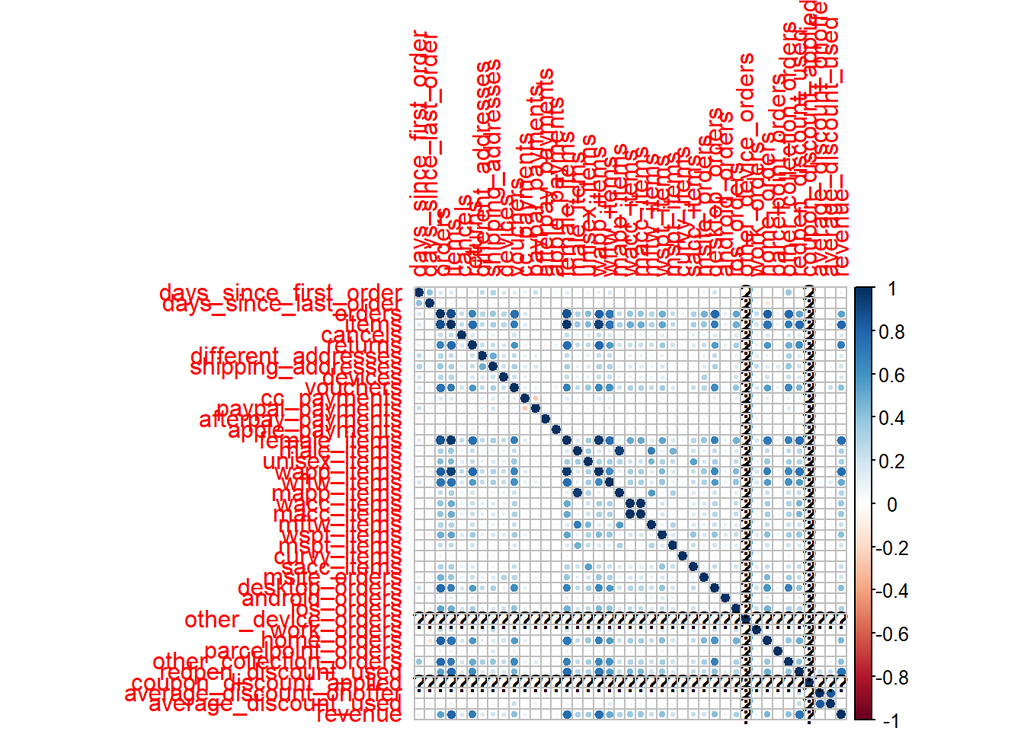

```r
#correlation plot
corrplot(as.matrix(Data_Correlation_Matrix))
```

### Stage 3:

Now We will start feature engineering to reduce the number of features for analysis and combine features to make them meaningful for analysis. The main purpose is to get the ratios and conversion rate for each product type segment and order.

```r
#Adding Average order value
Iconic_Test_Data_Clean <- mutate(Iconic_Test_Data_Clean, AOV = revenue/orders )

#Adding average number of items per orders
Iconic_Test_Data_Clean <- mutate(Iconic_Test_Data_Clean, ItemsPerOrder = items/orders)

#Cancellation Percentage
Iconic_Test_Data_Clean <- mutate(Iconic_Test_Data_Clean, CancellationRatio = 100 *cancels/orders)


#Adding Return Ratio'
Iconic_Test_Data_Clean <- mutate(Iconic_Test_Data_Clean, ReturnRatio = 100 *returns/orders)


#Vouchers Ratio = Vouchers per order
Iconic_Test_Data_Clean <- mutate(Iconic_Test_Data_Clean, VoucherRatio = 100 *vouchers/orders)

#FemaleItemsRatio
Iconic_Test_Data_Clean <- mutate(Iconic_Test_Data_Clean, FemaleItemsRatio = 100 *female_items/items)

#MaleItemsRatio
Iconic_Test_Data_Clean <- mutate(Iconic_Test_Data_Clean, MaleItemsRatio = 100 *male_items/items)

#UnisexRatio
Iconic_Test_Data_Clean <- mutate(Iconic_Test_Data_Clean, UnisexItemsRatio = 100 *unisex_items/items)

#wapp_itemsRatio
Iconic_Test_Data_Clean <- mutate(Iconic_Test_Data_Clean, WappItemsRatio = 100 *wapp_items/items)

#macc_itemsRatio
Iconic_Test_Data_Clean <- mutate(Iconic_Test_Data_Clean, MaccItemsRatio = 100 *macc_items/items)


#wftw_itemsRatio
Iconic_Test_Data_Clean <- mutate(Iconic_Test_Data_Clean, WftwItemsRatio = 100 *wftw_items/items)


#mapp_itemsRatio
Iconic_Test_Data_Clean <- mutate(Iconic_Test_Data_Clean, MappItemsRatio = 100 *mapp_items/items)

#wacc_itemsRatio
Iconic_Test_Data_Clean <- mutate(Iconic_Test_Data_Clean, WaccItemsRatio = 100 *wacc_items/items)

#mftw_itemsRatio
Iconic_Test_Data_Clean <- mutate(Iconic_Test_Data_Clean, MftwItemsRatio = 100 *mftw_items/items)

#wspt_itemsRatio
Iconic_Test_Data_Clean <- mutate(Iconic_Test_Data_Clean, WsptItemsRatio = 100 *wspt_items/items)

#mspt_itemsRatio
Iconic_Test_Data_Clean <- mutate(Iconic_Test_Data_Clean, MsptItemsRatio = 100 *mspt_items/items)

#curvy_itemsRatio
Iconic_Test_Data_Clean <- mutate(Iconic_Test_Data_Clean, CurvyItemsRatio = 100 *curvy_items/items)


#saccy_itemsRatio
Iconic_Test_Data_Clean <- mutate(Iconic_Test_Data_Clean, SaccItemsRatio = 100 *sacc_items/items)




#msite_ordersRatio
Iconic_Test_Data_Clean <- mutate(Iconic_Test_Data_Clean, MsiteOrdersRatio = 100 *msite_orders/orders)

#desktop_ordersRatio
Iconic_Test_Data_Clean <- mutate(Iconic_Test_Data_Clean, DesktopOrdersRatio = 100 *desktop_orders/orders)

#android_ordersRatio
Iconic_Test_Data_Clean <- mutate(Iconic_Test_Data_Clean, AndroidOrdersRatio = 100 *android_orders/orders)

#ios_ordersRatio
Iconic_Test_Data_Clean <- mutate(Iconic_Test_Data_Clean, IosOrdersRatio = 100 *ios_orders/orders)

#other_device_ordersRatio
Iconic_Test_Data_Clean <- mutate(Iconic_Test_Data_Clean, OtherDeviceOrdersRatio = 100 *other_device_orders/orders)

#work_ordersRatio
Iconic_Test_Data_Clean <- mutate(Iconic_Test_Data_Clean, WorkOrdersRatio = 100 *work_orders/orders)

#home_ordersRatio
Iconic_Test_Data_Clean <- mutate(Iconic_Test_Data_Clean, HomeOrdersRatio = 100 *home_orders/orders)


#parcelpoint_ordersRatio
Iconic_Test_Data_Clean <- mutate(Iconic_Test_Data_Clean, ParcelPointOrdersRatio = 100 *parcelpoint_orders/orders)


#other_collection_ordersRatio
Iconic_Test_Data_Clean <- mutate(Iconic_Test_Data_Clean, OtherCollectionOrdersRatio = 100 *other_collection_orders/orders)


#Revenue_Per_Order
Iconic_Test_Data_Clean <- mutate(Iconic_Test_Data_Clean, RevenuePerOrder = 100 *revenue/orders)
```

Now Lets select the features subset. We are selecting the ratio features that we created and the existing features that are not part of any ratio

```r
Iconic_Test_Data_Clean <- Iconic_Test_Data_Clean%>% select(customer_id
                            ,days_since_first_order
                            ,days_since_last_order
                            ,FemaleItemsRatio
                            ,MaleItemsRatio
                            ,UnisexItemsRatio
                            ,average_discount_onoffer
                            ,average_discount_used
                            ,ItemsPerOrder
                            ,CancellationRatio
                            ,ReturnRatio
                            ,VoucherRatio
                            ,WappItemsRatio
                            ,MaccItemsRatio
                            ,WftwItemsRatio
                            ,MappItemsRatio
                            ,WaccItemsRatio
                            ,MftwItemsRatio
                            ,WsptItemsRatio
                            ,MsptItemsRatio
                            ,CurvyItemsRatio
                            ,SaccItemsRatio
                            ,MsiteOrdersRatio
                            ,DesktopOrdersRatio
                            ,AndroidOrdersRatio
                            ,IosOrdersRatio
                            ,OtherDeviceOrdersRatio
                            ,WorkOrdersRatio
                            ,HomeOrdersRatio
                            ,ParcelPointOrdersRatio
                            ,OtherCollectionOrdersRatio
                            ,RevenuePerOrder


                            )
```

We need to normalize the data beacuse the days since first order and the days since last order are in higher numerical orders this will bias the output

```r
#First we will check for any non-numeric value being passed in the Normalize function and remove it.


which(apply(Iconic_Test_Data_Clean, 2, var)==0)
```

```
## OtherDeviceOrdersRatio
##                     27
```

```r
Iconic_Test_Data_Clean['OtherDeviceOrdersRatio'] = NULL

Iconic_Test_Data_Clean_Numeric =Iconic_Test_Data_Clean%>%keep(is.numeric)
summary(Iconic_Test_Data_Clean_Numeric)
```

```
##  days_since_first_order days_since_last_order FemaleItemsRatio
##  Min.   :  41           Min.   :  24          Min.   :  0.00
##  1st Qu.:1107           1st Qu.: 216          1st Qu.: 79.63
##  Median :1716           Median : 504          Median : 92.86
##  Mean   :1468           Mean   : 627          Mean   : 81.31
##  3rd Qu.:1820           3rd Qu.: 936          3rd Qu.:100.00
##  Max.   :2100           Max.   :2016          Max.   :100.00
##  MaleItemsRatio    UnisexItemsRatio  average_discount_onoffer
##  Min.   :  0.000   Min.   :  0.000   Min.   :0.0000
##  1st Qu.:  0.000   1st Qu.:  0.000   1st Qu.:0.0792
##  Median :  1.835   Median :  0.000   Median :0.1519
##  Mean   : 14.052   Mean   :  4.643   Mean   :0.1700
##  3rd Qu.: 14.074   3rd Qu.:  5.682   3rd Qu.:0.2427
##  Max.   :100.000   Max.   :100.000   Max.   :0.7500
##  average_discount_used ItemsPerOrder    CancellationRatio
##  Min.   :   0          Min.   : 1.000   Min.   : 0.0000
##  1st Qu.:1333          1st Qu.: 1.462   1st Qu.: 0.0000
##  Median :2277          Median : 1.909   Median : 0.0000
##  Mean   :2372          Mean   : 2.114   Mean   : 0.7728
##  3rd Qu.:3250          3rd Qu.: 2.500   3rd Qu.: 0.0000
##  Max.   :7500          Max.   :13.556   Max.   :53.8462
##   ReturnRatio       VoucherRatio     WappItemsRatio   MaccItemsRatio
##  Min.   :  0.000   Min.   :  0.000   Min.   :  0.00   Min.   :  0.000
##  1st Qu.:  4.167   1st Qu.:  8.333   1st Qu.: 31.71   1st Qu.:  0.000
##  Median : 27.273   Median : 20.000   Median : 53.85   Median :  3.226
##  Mean   : 43.205   Mean   : 23.547   Mean   : 49.67   Mean   :  6.548
##  3rd Qu.: 60.976   3rd Qu.: 35.484   3rd Qu.: 69.84   3rd Qu.:  9.091
##  Max.   :480.000   Max.   :100.000   Max.   :100.00   Max.   :100.000
##  WftwItemsRatio    MappItemsRatio    WaccItemsRatio    MftwItemsRatio
##  Min.   :  0.000   Min.   :  0.000   Min.   :  0.000   Min.   :  0.000
##  1st Qu.:  5.618   1st Qu.:  0.000   1st Qu.:  0.000   1st Qu.:  0.000
##  Median : 15.605   Median :  0.000   Median :  3.226   Median :  0.000
##  Mean   : 19.480   Mean   :  7.660   Mean   :  6.548   Mean   :  4.263
##  3rd Qu.: 27.451   3rd Qu.:  5.882   3rd Qu.:  9.091   3rd Qu.:  3.371
##  Max.   :100.000   Max.   :100.000   Max.   :100.000   Max.   :100.000
##  WsptItemsRatio    MsptItemsRatio   CurvyItemsRatio   SaccItemsRatio
##  Min.   :  0.000   Min.   : 0.000   Min.   : 0.0000   Min.   : 0.0000
##  1st Qu.:  0.000   1st Qu.: 0.000   1st Qu.: 0.0000   1st Qu.: 0.0000
##  Median :  0.000   Median : 0.000   Median : 0.0000   Median : 0.0000
##  Mean   :  5.582   Mean   : 1.016   Mean   : 0.3237   Mean   : 0.9911
```

[output cut: 8 more lines]

```
##  Max.   :100.00   Max.   :100.00     Max.   :100.00     Max.   :100.00
##  WorkOrdersRatio   HomeOrdersRatio  ParcelPointOrdersRatio
##  Min.   :  0.000   Min.   :  0.00   Min.   :  0.0000
##  1st Qu.:  0.000   1st Qu.: 33.33   1st Qu.:  0.0000
##  Median :  0.000   Median : 54.17   Median :  0.0000
##  Mean   :  9.081   Mean   : 54.32   Mean   :  0.8841
##  3rd Qu.:  0.000   3rd Qu.: 77.78   3rd Qu.:  0.0000
##  Max.   :100.000   Max.   :100.00   Max.   :100.0000
##  OtherCollectionOrdersRatio RevenuePerOrder
##  Min.   :  0.00             Min.   :    435.6
##  1st Qu.: 14.29             1st Qu.:  13723.8
##  Median : 33.33             Median :  22355.6
##  Mean   : 35.71             Mean   :  36226.9
##  3rd Qu.: 54.17             3rd Qu.:  39364.8
##  Max.   :100.00             Max.   :1294924.1
```

```r
#creating a normalization funtion here
normalize <- function(x) {
  return ((x - min(x)) / (max(x) - min(x)))
}

dfNorm <- as.data.frame(lapply(Iconic_Test_Data_Clean_Numeric, normalize))
```

Now we will apply the Principal Component Analysis on the Data to reduce variables

```r
pca_Iconic_data<-prcomp(na.omit(dfNorm),center = TRUE,scale. = TRUE)
#Iconic_Test_Data_Clean['other_device_orders'] = NULL
summary(pca_Iconic_data)
```

```
## Importance of components:
##                          PC1     PC2     PC3     PC4     PC5     PC6
## Standard deviation     2.005 1.62740 1.62698 1.40455 1.37940 1.28547
## Proportion of Variance 0.134 0.08828 0.08824 0.06576 0.06342 0.05508
## Cumulative Proportion  0.134 0.22228 0.31051 0.37627 0.43970 0.49478
##                            PC7     PC8     PC9    PC10    PC11    PC12
## Standard deviation     1.22127 1.11902 1.08814 1.04774 1.02590 1.01165
## Proportion of Variance 0.04972 0.04174 0.03947 0.03659 0.03508 0.03411
## Cumulative Proportion  0.54449 0.58623 0.62570 0.66229 0.69738 0.73149
##                           PC13    PC14    PC15    PC16    PC17    PC18
## Standard deviation     1.00130 0.99430 0.97351 0.94493 0.91297 0.90240
## Proportion of Variance 0.03342 0.03295 0.03159 0.02976 0.02778 0.02714
## Cumulative Proportion  0.76491 0.79786 0.82946 0.85922 0.88700 0.91415
##                           PC19    PC20    PC21    PC22    PC23    PC24
## Standard deviation     0.87549 0.72374 0.70771 0.61559 0.45094 0.31108
## Proportion of Variance 0.02555 0.01746 0.01669 0.01263 0.00678 0.00323
## Cumulative Proportion  0.93970 0.95716 0.97385 0.98648 0.99326 0.99649
##                           PC25    PC26      PC27      PC28     PC29
## Standard deviation     0.29318 0.13958 1.851e-15 1.562e-15 1.47e-15
## Proportion of Variance 0.00287 0.00065 0.000e+00 0.000e+00 0.00e+00
## Cumulative Proportion  0.99935 1.00000 1.000e+00 1.000e+00 1.00e+00
##                             PC30
## Standard deviation     1.359e-15
## Proportion of Variance 0.000e+00
## Cumulative Proportion  1.000e+00
```

We can see that the 14 components explains almost 80% of the variance in the data. We can select these 14 components to build our model.

First lets select and Plot the principal components.

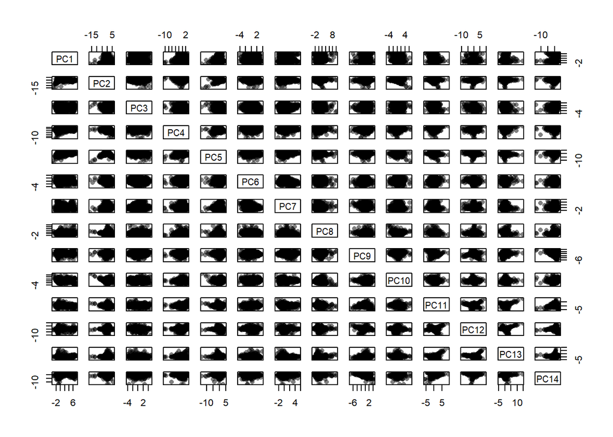

```r
principle_components <- data.frame(pca_Iconic_data$x[,1:14])
# Plot the principle components
plot(principle_components, pch=16, col=rgb(0,0,0,0.5))
```

Since prinipal component analysis is hard to explain to business users. I will discard this approach and use K-means clustering on normalized data.

Now we will apply simple unsupervised learning technique to find the segments.

I am using K-means clustering techniques because its very simple to apply and understand.

First lets try figuring out the number of clusters we need

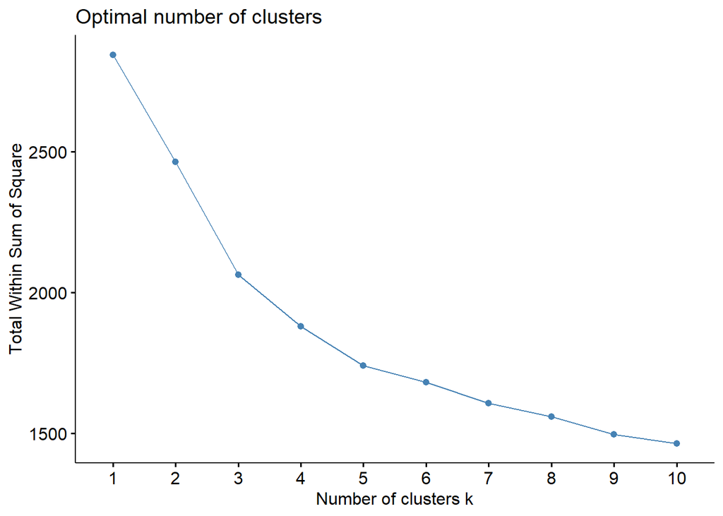

```r
fviz_nbclust(dfNorm, kmeans, method = "wss")
```

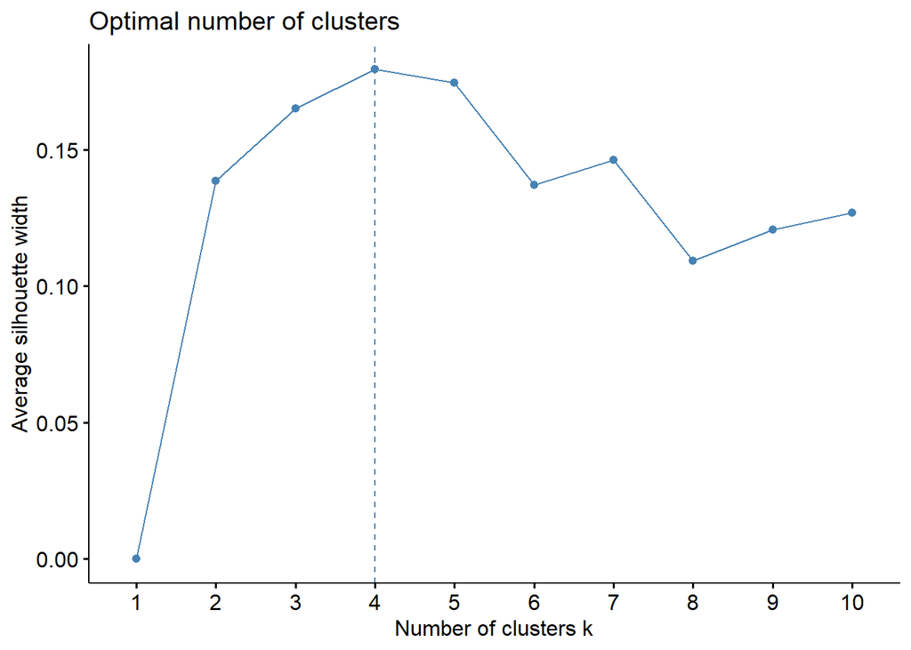

```r
fviz_nbclust(dfNorm, kmeans, method = "silhouette")
```

Now lets build the clustering analysis for k=2,3,4 clusters

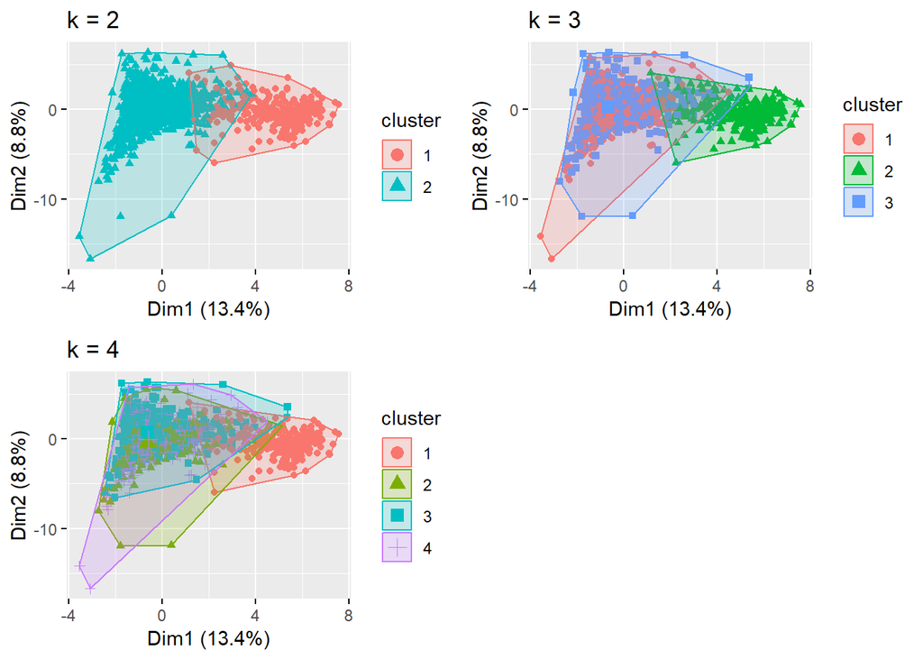

```r
set.seed(123)
k2 <- kmeans(na.omit(dfNorm), centers = 2, nstart = 25)
k3 <- kmeans(na.omit(dfNorm), centers = 3, nstart = 25)
k4 <- kmeans(na.omit(dfNorm), centers = 4, nstart = 25)


# plots to compare
p2 <- fviz_cluster(k2, geom = "point", data = na.omit(dfNorm))+ ggtitle("k = 2")
p3 <- fviz_cluster(k3, geom = "point",  data = na.omit(dfNorm)) + ggtitle("k = 3")
p4 <- fviz_cluster(k4, geom = "point",  data = na.omit(dfNorm)) + ggtitle("k = 4")
grid.arrange(p2, p3, p4, nrow = 2)
```

```r
k2
```

```
## K-means clustering with 2 clusters of sizes 322, 2355
##
## Cluster means:
##   days_since_first_order days_since_last_order FemaleItemsRatio
## 1              0.6564454             0.3147123        0.1334811
## 2              0.6981875             0.3010872        0.9059683
##   MaleItemsRatio UnisexItemsRatio average_discount_onoffer
## 1     0.75581247       0.11070640                0.2361917
## 2     0.05639566       0.03763601                0.2253990
##   average_discount_used ItemsPerOrder CancellationRatio ReturnRatio
## 1             0.3168919    0.08563680        0.01361355  0.05749758
## 2             0.3161696    0.08914563        0.01445332  0.09445661
##   VoucherRatio WappItemsRatio MaccItemsRatio WftwItemsRatio MappItemsRatio
## 1    0.2343676     0.05779669     0.02621514      0.0457109     0.43246038
## 2    0.2356239     0.55665816     0.07084484      0.2151803     0.02794808
```

[output cut: 382 more lines]

```r
#plot(na.omit(dfNorm), k2$cluster)
```

As you can see apart when we use 3 or 4 cluster we get subcluster for one cluster.That means we are getting deeper clusters. Here we want to predict the gender so I will just go with 2 clusters.

I will insert the k2 cluster results in the **Iconic_Test_Data_Clean** dataframe.

```r
Iconic_Test_Data_Clean_Clusters <- mutate(Iconic_Test_Data_Clean, Cluster = k2$cluster)
```

Now we have our data labelled with 2 different cluster and by inspecting the data it seems like majority of the customers in bigger cluster are have high FemaleItemRatio and lower MaleItemRatio. This, however, can’t be conclusive to infer gender as sometimes its not true and we have other factors that we want to consider to rightly predict the gender.

To do that, we will apply the random forest technique and split our data into test and training set.

```r
#install the randomforest package if its not already installed
if(!require(randomForest)) install.packages("randomForest",repos ="http://cran.us.r-project.org")

set.seed(123)

#Create the train sample split

train_data <- sample(nrow(Iconic_Test_Data_Clean_Clusters),0.7*nrow(Iconic_Test_Data_Clean_Clusters), replace = FALSE)


#Store the Training data in TrainSet
TrainSet <- Iconic_Test_Data_Clean_Clusters[train_data,]

#Store the Validiation dataset in ValidSet
ValidSet <- Iconic_Test_Data_Clean_Clusters[-train_data,]


#Print the Summary of the train and valid data to see the data split
summary(TrainSet)
```

```
##  customer_id        days_since_first_order days_since_last_order
##  Length:1873        Min.   :  49           Min.   :  24.0
##  Class :character   1st Qu.:1122           1st Qu.: 192.0
##  Mode  :character   Median :1717           Median : 504.0
##                     Mean   :1474           Mean   : 631.2
##                     3rd Qu.:1817           3rd Qu.: 960.0
##                     Max.   :2100           Max.   :2016.0
##  FemaleItemsRatio MaleItemsRatio    UnisexItemsRatio
##  Min.   :  0.00   Min.   :  0.000   Min.   :  0.000
##  1st Qu.: 80.00   1st Qu.:  0.000   1st Qu.:  0.000
##  Median : 92.86   Median :  1.961   Median :  0.000
##  Mean   : 81.48   Mean   : 14.024   Mean   :  4.492
##  3rd Qu.:100.00   3rd Qu.: 14.118   3rd Qu.:  5.357
##  Max.   :100.00   Max.   :100.000   Max.   :100.000
##  average_discount_onoffer average_discount_used ItemsPerOrder
##  Min.   :0.0000           Min.   :   0          Min.   : 1.000
##  1st Qu.:0.0780           1st Qu.:1307          1st Qu.: 1.464
##  Median :0.1500           Median :2265          Median : 1.912
##  Mean   :0.1684           Mean   :2350          Mean   : 2.123
##  3rd Qu.:0.2414           3rd Qu.:3229          3rd Qu.: 2.500
##  Max.   :0.7500           Max.   :7500          Max.   :13.556
##  CancellationRatio  ReturnRatio       VoucherRatio     WappItemsRatio
##  Min.   : 0.0000   Min.   :  0.000   Min.   :  0.000   Min.   :  0.00
##  1st Qu.: 0.0000   1st Qu.:  4.444   1st Qu.:  8.333   1st Qu.: 32.43
##  Median : 0.0000   Median : 27.273   Median : 20.000   Median : 54.55
##  Mean   : 0.7675   Mean   : 43.299   Mean   : 23.327   Mean   : 50.00
##  3rd Qu.: 0.0000   3rd Qu.: 60.000   3rd Qu.: 35.000   3rd Qu.: 69.64
##  Max.   :53.8462   Max.   :480.000   Max.   :100.000   Max.   :100.00
##  MaccItemsRatio    WftwItemsRatio    MappItemsRatio    WaccItemsRatio
##  Min.   :  0.000   Min.   :  0.000   Min.   :  0.000   Min.   :  0.000
##  1st Qu.:  0.000   1st Qu.:  5.714   1st Qu.:  0.000   1st Qu.:  0.000
##  Median :  3.226   Median : 15.556   Median :  0.000   Median :  3.226
##  Mean   :  6.548   Mean   : 19.164   Mean   :  7.601   Mean   :  6.548
##  3rd Qu.:  9.091   3rd Qu.: 26.984   3rd Qu.:  5.814   3rd Qu.:  9.091
##  Max.   :100.000   Max.   :100.000   Max.   :100.000   Max.   :100.000
##  MftwItemsRatio    WsptItemsRatio    MsptItemsRatio    CurvyItemsRatio
##  Min.   :  0.000   Min.   :  0.000   Min.   : 0.0000   Min.   : 0.0000
##  1st Qu.:  0.000   1st Qu.:  0.000   1st Qu.: 0.0000   1st Qu.: 0.0000
##  Median :  0.000   Median :  0.000   Median : 0.0000   Median : 0.0000
##  Mean   :  4.295   Mean   :  5.681   Mean   : 0.9575   Mean   : 0.3553
```

[output cut: 15 more lines]

```
##  Max.   :100.00   Max.   :100.000   Max.   :100.00
##  ParcelPointOrdersRatio OtherCollectionOrdersRatio RevenuePerOrder
##  Min.   : 0.0000        Min.   :  0.00             Min.   :    435.6
##  1st Qu.: 0.0000        1st Qu.: 14.29             1st Qu.:  13865.0
##  Median : 0.0000        Median : 33.33             Median :  22243.6
##  Mean   : 0.7919        Mean   : 35.89             Mean   :  37073.3
##  3rd Qu.: 0.0000        3rd Qu.: 54.55             3rd Qu.:  39317.0
##  Max.   :80.0000        Max.   :100.00             Max.   :1294924.1
##     Cluster
##  Min.   :1.000
##  1st Qu.:2.000
##  Median :2.000
##  Mean   :1.879
##  3rd Qu.:2.000
##  Max.   :2.000
```

```r
summary(ValidSet)
```

```
##  customer_id        days_since_first_order days_since_last_order
##  Length:804         Min.   :  41           Min.   :  24.0
##  Class :character   1st Qu.:1075           1st Qu.: 216.0
##  Mode  :character   Median :1715           Median : 504.0
##                     Mean   :1455           Mean   : 617.3
##                     3rd Qu.:1827           3rd Qu.: 888.0
##                     Max.   :2090           Max.   :2016.0
##  FemaleItemsRatio MaleItemsRatio    UnisexItemsRatio
##  Min.   :  0.00   Min.   :  0.000   Min.   :  0.0000
##  1st Qu.: 78.54   1st Qu.:  0.000   1st Qu.:  0.0000
##  Median : 92.76   Median :  1.462   Median :  0.9303
##  Mean   : 80.89   Mean   : 14.120   Mean   :  4.9929
##  3rd Qu.:100.00   3rd Qu.: 13.853   3rd Qu.:  6.2500
##  Max.   :100.00   Max.   :100.000   Max.   :100.0000
##  average_discount_onoffer average_discount_used ItemsPerOrder
##  Min.   :0.00000          Min.   :   0          Min.   :1.000
##  1st Qu.:0.08175          1st Qu.:1395          1st Qu.:1.451
##  Median :0.15800          Median :2327          Median :1.900
##  Mean   :0.17374          Mean   :2424          Mean   :2.093
##  3rd Qu.:0.24340          3rd Qu.:3297          3rd Qu.:2.477
##  Max.   :0.64670          Max.   :6976          Max.   :6.294
##  CancellationRatio  ReturnRatio      VoucherRatio     WappItemsRatio
##  Min.   : 0.0000   Min.   :  0.00   Min.   :  0.000   Min.   :  0.00
##  1st Qu.: 0.0000   1st Qu.:  0.00   1st Qu.:  8.439   1st Qu.: 28.57
##  Median : 0.0000   Median : 28.29   Median : 20.000   Median : 53.16
##  Mean   : 0.7852   Mean   : 42.99   Mean   : 24.060   Mean   : 48.89
##  3rd Qu.: 0.0000   3rd Qu.: 62.50   3rd Qu.: 36.439   3rd Qu.: 70.33
##  Max.   :50.0000   Max.   :386.67   Max.   :100.000   Max.   :100.00
##  MaccItemsRatio   WftwItemsRatio    MappItemsRatio    WaccItemsRatio
##  Min.   : 0.000   Min.   :  0.000   Min.   :  0.000   Min.   : 0.000
##  1st Qu.: 0.000   1st Qu.:  5.263   1st Qu.:  0.000   1st Qu.: 0.000
##  Median : 3.165   Median : 15.752   Median :  0.000   Median : 3.165
##  Mean   : 6.547   Mean   : 20.215   Mean   :  7.799   Mean   : 6.547
##  3rd Qu.: 8.806   3rd Qu.: 28.571   3rd Qu.:  6.250   3rd Qu.: 8.806
##  Max.   :83.333   Max.   :100.000   Max.   :100.000   Max.   :83.333
##  MftwItemsRatio    WsptItemsRatio   MsptItemsRatio   CurvyItemsRatio
##  Min.   :  0.000   Min.   : 0.000   Min.   : 0.000   Min.   : 0.00
##  1st Qu.:  0.000   1st Qu.: 0.000   1st Qu.: 0.000   1st Qu.: 0.00
##  Median :  0.000   Median : 0.000   Median : 0.000   Median : 0.00
##  Mean   :  4.190   Mean   : 5.351   Mean   : 1.152   Mean   : 0.25
```

[output cut: 15 more lines]

```
##  Max.   :100.00   Max.   :100.000   Max.   :100.00
##  ParcelPointOrdersRatio OtherCollectionOrdersRatio RevenuePerOrder
##  Min.   :  0.000        Min.   :  0.00             Min.   :  1469
##  1st Qu.:  0.000        1st Qu.: 14.95             1st Qu.: 13329
##  Median :  0.000        Median : 33.33             Median : 22948
##  Mean   :  1.099        Mean   : 35.29             Mean   : 34255
##  3rd Qu.:  0.000        3rd Qu.: 50.00             3rd Qu.: 39412
##  Max.   :100.000        Max.   :100.00             Max.   :506487
##     Cluster
##  Min.   :1.000
##  1st Qu.:2.000
##  Median :2.000
##  Mean   :1.882
##  3rd Qu.:2.000
##  Max.   :2.000
```

```r
#Convert the Cluster as factor for prediction

TrainSet$Cluster <- as.character(TrainSet$Cluster)
TrainSet$Cluster <- as.factor(TrainSet$Cluster)



ValidSet$Cluster <- as.character(ValidSet$Cluster)
ValidSet$Cluster <- as.factor(ValidSet$Cluster)


#RandomForest Model


RandomForest_Model <- randomForest(Cluster ~
                       days_since_first_order
                       +days_since_last_order
                       +FemaleItemsRatio
                       +MaleItemsRatio
                       +UnisexItemsRatio
                       +average_discount_onoffer
                       +average_discount_used
                       +ItemsPerOrder
                       +CancellationRatio
                       +ReturnRatio
                       +VoucherRatio
                       +WappItemsRatio
                       +MaccItemsRatio
                       +WftwItemsRatio
                       +MappItemsRatio
                       +WaccItemsRatio
                       +MftwItemsRatio
                       +WsptItemsRatio
                       +MsptItemsRatio
                       +CurvyItemsRatio
                       +SaccItemsRatio
                       +MsiteOrdersRatio
                       +DesktopOrdersRatio
                       +AndroidOrdersRatio
                       +IosOrdersRatio
                       +WorkOrdersRatio
                       +HomeOrdersRatio
                       +ParcelPointOrdersRatio
                       +OtherCollectionOrdersRatio
                       +RevenuePerOrder, data = TrainSet,importance = TRUE)




RandomForest_Model
```

```
##
## Call:
##  randomForest(formula = Cluster ~ days_since_first_order + days_since_last_order +      FemaleItemsRatio + MaleItemsRatio + UnisexItemsRatio + average_discount_onoffer +      average_discount_used + ItemsPerOrder + CancellationRatio +      ReturnRatio + VoucherRatio + WappItemsRatio + MaccItemsRa…
##                Type of random forest: classification
##                      Number of trees: 500
## No. of variables tried at each split: 5
##
##         OOB estimate of  error rate: 0.48%
## Confusion matrix:
##     1    2 class.error
## 1 222    5 0.022026432
## 2   4 1642 0.002430134
```

```r
# Predicting on train set to see how our model is preforming on the data we used for builing it


predTrain <- predict(RandomForest_Model, TrainSet, type = "class")


# Checking classification accuracy
table(predTrain, TrainSet$Cluster)
```

```
##
## predTrain    1    2
##         1  227    0
##         2    0 1646
```

```r
# Predicting on Validation set
predValid <- predict(RandomForest_Model, ValidSet, type = "class")


# Checking classification accuracy
mean(predValid == ValidSet$Cluster)
```

```
## [1] 0.9912935
```

```r
table(predValid,ValidSet$Cluster)
```

```
##
## predValid   1   2
##         1  92   4
##         2   3 705
```

```r
# To check importance of different variables
importance(RandomForest_Model)
```

```
##                                      1            2 MeanDecreaseAccuracy
## days_since_first_order      0.20302434  1.172006875           1.16669457
## days_since_last_order      -1.53438307  2.289483282           1.17996078
## FemaleItemsRatio           27.39160507 26.567311844          32.95379861
## MaleItemsRatio             22.02215421 20.854212345          26.48716283
## UnisexItemsRatio            1.78275630  7.208600482           7.52405377
## average_discount_onoffer   -0.86875455  1.372328074           1.17269812
## average_discount_used      -0.79482453  1.378476004           1.14825713
## ItemsPerOrder               2.95323972  0.977456951           2.21850770
## CancellationRatio          -0.65853334  0.005894505          -0.48303426
## ReturnRatio                 2.41165541  3.939464392           4.70381034
## VoucherRatio               -0.15841849 -0.059590181          -0.08907842
## WappItemsRatio             15.45517459  8.070754769          16.92882469
## MaccItemsRatio              5.13808218  3.221982107           5.73347392
## WftwItemsRatio              8.74704902  7.860471810          11.44663030
## MappItemsRatio             11.16725825 13.694610395          16.23132500
## WaccItemsRatio              5.41707939  3.177174680           5.94029978
## MftwItemsRatio             10.04415975 11.127290960          13.74807446
## WsptItemsRatio              4.34329778  2.783305675           4.64927035
## MsptItemsRatio              0.37225022  6.608611353           6.52460729
## CurvyItemsRatio             0.51889567  0.192842813           0.34907729
## SaccItemsRatio             -2.19246872  0.186981877          -1.17051888
## MsiteOrdersRatio            2.27151737 -0.033893378           1.54826455
## DesktopOrdersRatio          2.60165352  1.295911527           2.74528353
## AndroidOrdersRatio          2.13083941 -1.087810257           0.42142630
## IosOrdersRatio              0.54777164  2.555311984           2.25826929
## WorkOrdersRatio             0.02033593  1.497096517           1.24719202
## HomeOrdersRatio            -0.13325796  2.838870371           2.73267582
## ParcelPointOrdersRatio     -1.07598306  0.867165647           0.20938523
## OtherCollectionOrdersRatio  0.47066256  1.918083854           1.96249887
## RevenuePerOrder             0.36713246  1.857671595           1.82369013
##                            MeanDecreaseGini
## days_since_first_order            1.5011529
## days_since_last_order             1.3962124
## FemaleItemsRatio                122.1727482
## MaleItemsRatio                   98.8341656
## UnisexItemsRatio                  4.5578218
## average_discount_onoffer          1.5385089
## average_discount_used             1.4044583
## ItemsPerOrder                     1.5406056
## CancellationRatio                 0.2373616
## ReturnRatio                       1.1709196
## VoucherRatio                      0.8912330
## WappItemsRatio                   45.5524791
## MaccItemsRatio                    4.2071935
## WftwItemsRatio                   15.2052200
## MappItemsRatio                   50.2285268
## WaccItemsRatio                    4.5797555
## MftwItemsRatio                   25.2038219
## WsptItemsRatio                    2.5400989
## MsptItemsRatio                    6.3659259
## CurvyItemsRatio                   0.2465825
## SaccItemsRatio                    0.5826968
## MsiteOrdersRatio                  0.8782029
## DesktopOrdersRatio                1.1441253
## AndroidOrdersRatio                0.3233239
## IosOrdersRatio                    0.6025280
## WorkOrdersRatio                   0.6038567
## HomeOrdersRatio                   1.2037629
## ParcelPointOrdersRatio            0.1793855
## OtherCollectionOrdersRatio        1.0030297
## RevenuePerOrder                   2.1355928
```

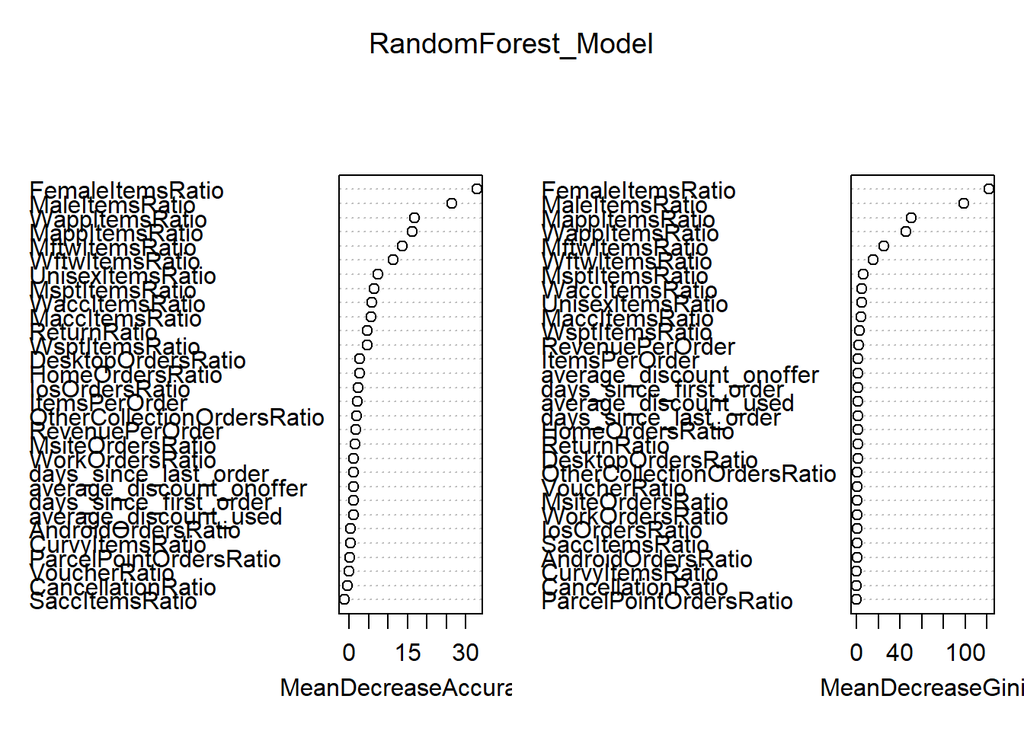

```r
#plot the important variable of RandomForest
varImpPlot(RandomForest_Model)
```

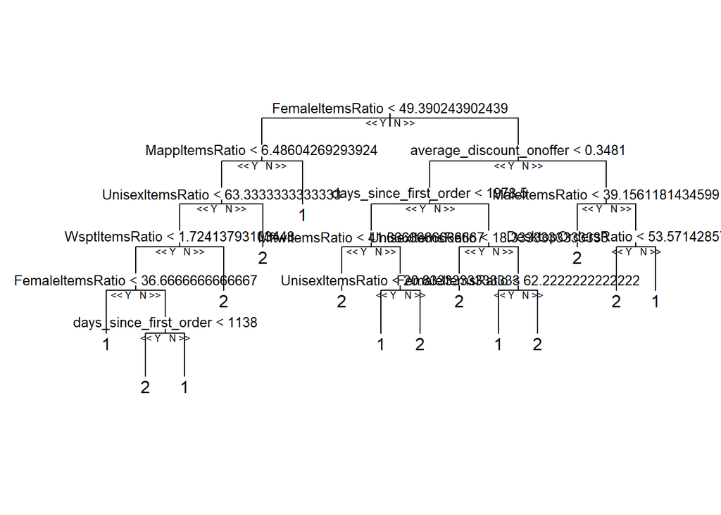

```r
#Now Lets Plot the Random Forest and Interpert the Gender

reprtree:::plot.getTree(RandomForest_Model)
```

We can see the important variables from importance function and varImpPlot output are: FemaleItemsRatio MaleItemsRatio WappItemsRatio MappItemsRatio MftwItemsRatio WftwItemsRatio

We will now just use thes features to build our model again.

```r
#RandomForest Model


RandomForest_Model2 <- randomForest(Cluster ~ FemaleItemsRatio+MaleItemsRatio+WappItemsRatio
                       +WftwItemsRatio+MappItemsRatio+MftwItemsRatio
                       , data = TrainSet,importance = TRUE)




RandomForest_Model2
```

```
##
## Call:
##  randomForest(formula = Cluster ~ FemaleItemsRatio + MaleItemsRatio +      WappItemsRatio + WftwItemsRatio + MappItemsRatio + MftwItemsRatio,      data = TrainSet, importance = TRUE)
##                Type of random forest: classification
##                      Number of trees: 500
## No. of variables tried at each split: 2
##
##         OOB estimate of  error rate: 0.48%
## Confusion matrix:
##     1    2 class.error
## 1 222    5 0.022026432
## 2   4 1642 0.002430134
```

```r
# Predicting on train set to see how our model is preforming on the data we used for builing it


predTrain <- predict(RandomForest_Model2, TrainSet, type = "class")


# Checking classification accuracy
table(predTrain, TrainSet$Cluster)
```

```
##
## predTrain    1    2
##         1  227    0
##         2    0 1646
```

```r
# Predicting on Validation set
predValid <- predict(RandomForest_Model2, ValidSet, type = "class")


# Checking classification accuracy
mean(predValid == ValidSet$Cluster)
```

```
## [1] 0.9937811
```

```r
table(predValid,ValidSet$Cluster)
```

```
##
## predValid   1   2
##         1  94   4
##         2   1 705
```

```r
# To check importance of different variables
importance(RandomForest_Model2)
```

```
##                          1         2 MeanDecreaseAccuracy MeanDecreaseGini
## FemaleItemsRatio 27.652692 26.510124            37.172460       166.136723
## MaleItemsRatio   22.616572 18.034840            27.504107       124.404964
## WappItemsRatio   13.917060  2.304514            14.001194        34.833939
## WftwItemsRatio    6.452764  4.152107             7.704961         4.533569
## MappItemsRatio    8.769230  8.786701            10.602184        52.142034
## MftwItemsRatio    8.526676  5.455788             8.676296        15.211346
```

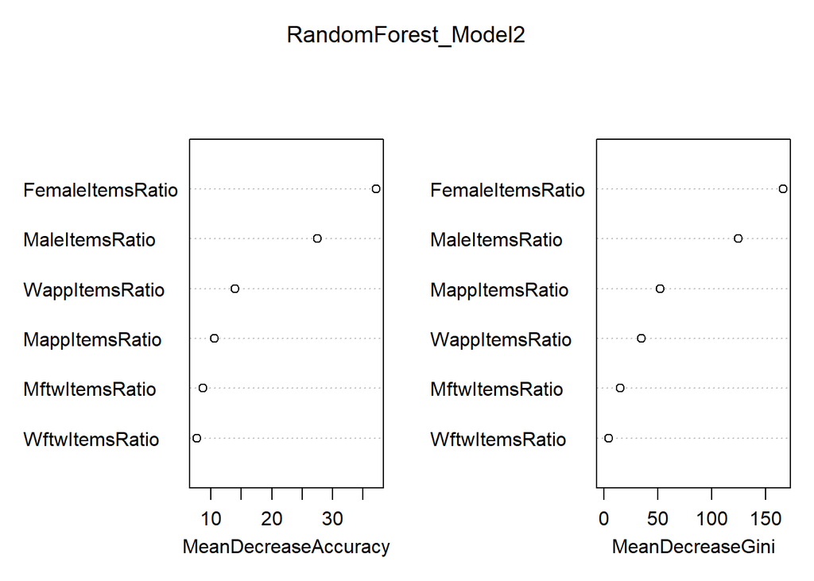

```r
#plot the important variable of RandomForest
varImpPlot(RandomForest_Model2)
```

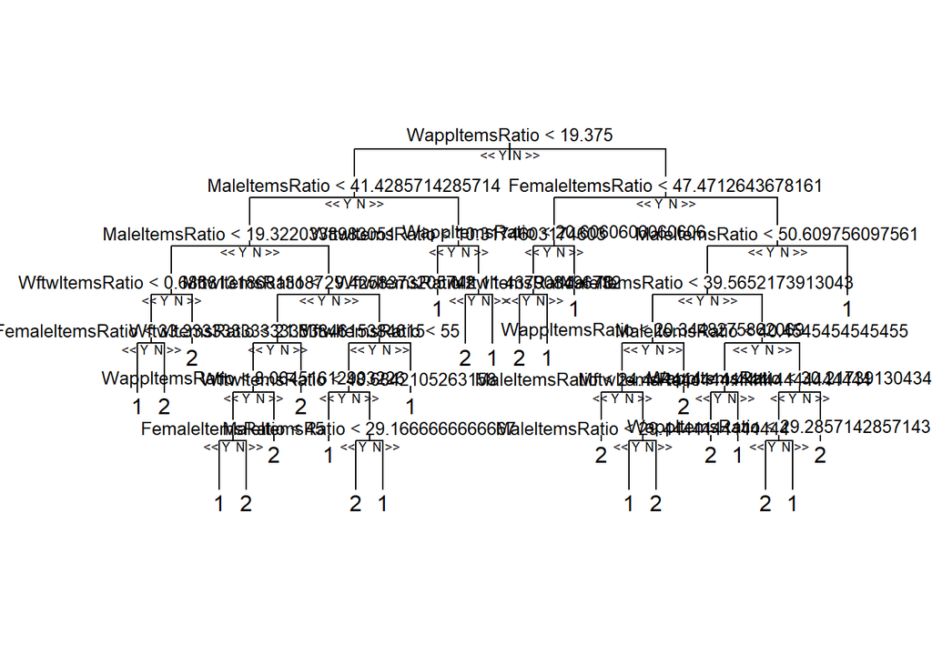

```r
#Now Lets Plot the Random Forest and Interpert the Gender

reprtree:::plot.getTree(RandomForest_Model2)
```

```r
#Create the Technical Explantory Note for the random forest
#explain_forest(RandomForest_Model, interactions = TRUE, data = TrainSet)
```

By using just 6 variables we don’t have any impact on our model accuracy and its still 99 percent.

The Tree now is much more easy to understand and explain. Lets have a look at the tree now and try interperting it.

As we can see from this inference that most of the time cluster 2 have more female dominant features cluster 2 is female and cluster 1 have more male dominant features cluster 1 is male.